# Statistical Computing Final Project

MustafaCanİnce-200709081

2023-06-14

## 1. (3p) Data:

Please find your original dataset or datasets; and describe your data in the first step

The data set includes the scores I have given to the movies and series I have watched since 2019, the average of imdb users, the genre of the movie and the series, the director, the release year, my voting date, id, duration, name.

https://www.imdb.com/user/ur108869947/

```r
my_data <- read.csv('ratings.csv')

print(head(my_data, 10))
```

```
##         Const Your.Rating Date.Rated                            Title
## 1   tt1014759           5 2020-01-16              Alice in Wonderland
## 2   tt0101540           8 2022-09-12                        Cape Fear
## 3   tt1024648           7 2023-03-26                             Argo
## 4   tt0102926           8 2019-10-21         The Silence of the Lambs
## 5   tt0103064           6 2020-02-13       Terminator 2: Judgment Day
## 6   tt1049413           7 2020-03-03                               Up
## 7   tt0105236           8 2019-10-16                   Reservoir Dogs
## 8  tt10551256           4 2021-03-23 Age of Samurai: Battle for Japan
## 9   tt0105695           9 2022-02-15                       Unforgiven
## 10 tt10640346           8 2023-03-11                          Babylon
##                                       URL   Title.Type IMDb.Rating
## 1   https://www.imdb.com/title/tt1014759/        movie         6.4
## 2   https://www.imdb.com/title/tt0101540/        movie         7.3
## 3   https://www.imdb.com/title/tt1024648/        movie         7.7
```

[output cut: 29 more lines]

## 2. (3p) Exploratory and descriptive data analysis:

Use “Exploratory and descriptive data analysis”. Talk about your categorical and quantitative data or your ordinal variables etc. Write down your comments

```
##  [1] "Const"          "Your.Rating"    "Date.Rated"     "Title"
##  [5] "URL"            "Title.Type"     "IMDb.Rating"    "Runtime..mins."
##  [9] "Year"           "Genres"         "Num.Votes"      "Release.Date"
## [13] "Directors"
```

Const : (‘tt1014759’, tt0101540, …) Your.Rating: (‘5’, ‘8’, …)

URL:(‘https://www.imdb.com/title/tt1014759/’,‘https://www.imdb.com/title/tt0101540/’,…) Title.Type: (‘movie’,‘movie’, …) IMDb.Rating: (‘6.4’, ‘7.3’, …) Runtime..mins.: (‘108’,‘128’, …) Year: (‘2010’, ‘1991’, …) Genres: (‘Adventure, Family,Fantasy, Mystery’, ‘Crime, Thriller’, …) Num.Votes: (‘426039’,‘204632’, …) Release.Date:(‘2/25/2010’,‘10/6/1991’, …), (mm, dd,yyyy) Directors: (‘Tim Burton’, ‘Martin Scorsese’, …)

Categorical Variables: ‘Const’, ‘Title’, ‘Title.Type’, ‘Genres’

Ordinal Variables: ‘Your.Rating’

Interval Variables: ‘Date.Rated’, ‘Runtime..mins.’, ‘Year’, ‘Num.Votes’, ‘Release.Date’

Quantitative Variable: ‘IMDb.Rating’

## 3. (3p) Data Visualization:

Use at least 4 useful, meaningful and different “data visualization techniques” which will help you understand your data further (distribution, outliers, variability, etc). Use 2 of the visualizations to compare two groups (like female/male; smoker/non-smoker etc).

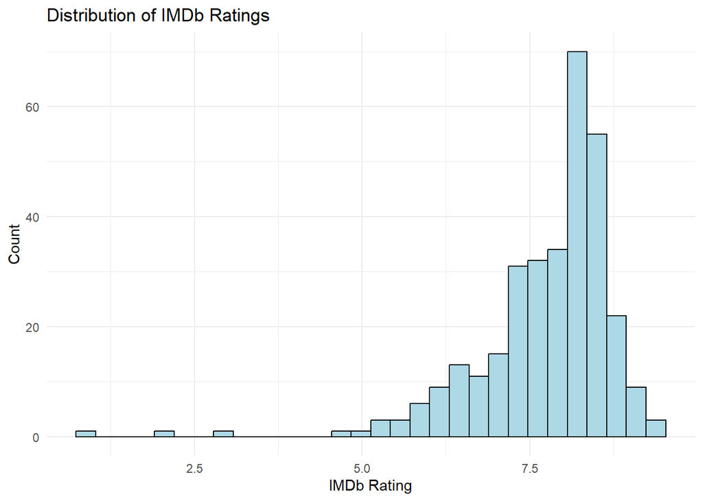

```r
# Rename the columns to match the dataset
colnames(my_data) <- c("Const", "Your_Rating", "Date_Rated", "Title", "URL", "Title_Type", "IMDb_Rating", "Runtime_mins", "Year", "Genres", "Num_Votes", "Release_Date", "Directors")

# Data visualization techniques

# 1. Histogram of IMDb Ratings
ggplot(my_data, aes(x = IMDb_Rating)) +
  geom_histogram(fill = "lightblue", color = "black") +
  labs(title = "Distribution of IMDb Ratings", x = "IMDb Rating", y = "Count") +
  theme_minimal()
```

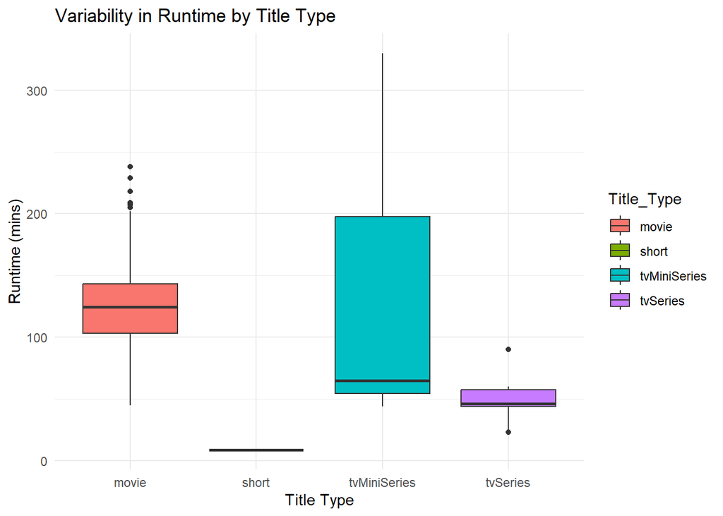

```r
# 2. Boxplot of Runtime by Title Type
ggplot(my_data, aes(x = Title_Type, y = Runtime_mins, fill = Title_Type)) +
  geom_boxplot() +
  labs(title = "Variability in Runtime by Title Type", x = "Title Type", y = "Runtime (mins)") +
  theme_minimal()
```

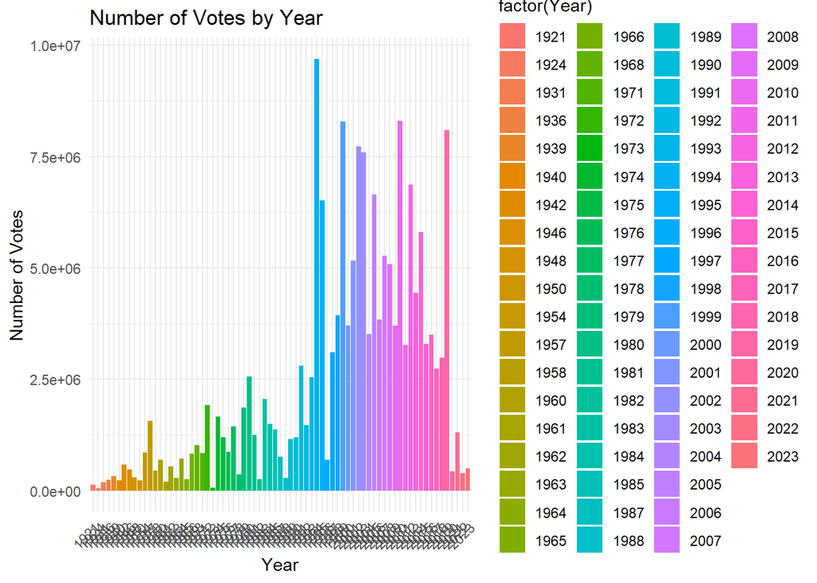

```r
# 3. Barplot of Number of Votes by Year
ggplot(my_data, aes(x = factor(Year), y = Num_Votes, fill = factor(Year))) +
  geom_bar(stat = "identity") +
  labs(title = "Number of Votes by Year", x = "Year", y = "Number of Votes") +
  theme_minimal() +
  theme(axis.text.x = element_text(angle = 45, hjust = 1)) +
  scale_x_discrete(expand = c(0.01, 0.01))
```

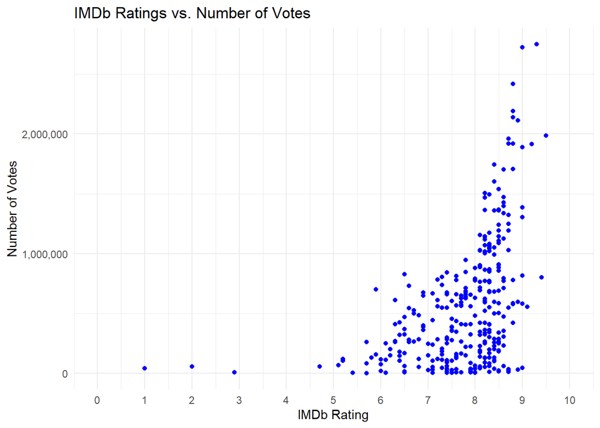

```r
# 4. Scatterplot of IMDb Ratings vs. Num Votes
ggplot(my_data, aes(x = IMDb_Rating, y = Num_Votes)) +
  geom_point(color = "blue") +
  scale_x_continuous(limits = c(0, 10), breaks = seq(0, 10, 1)) +
  scale_y_continuous(labels = comma) +
  labs(title = "IMDb Ratings vs. Number of Votes", x = "IMDb Rating", y = "Number of Votes") +
  theme_minimal()
```

## 4. (3p) Confidence Intervals:

Build ‘2 Confidence Intervals’ step by step: Calculate the mean, then standard error, and then the CI. Make “clear comments” about your findings

```r
mean_rating <- mean(my_data$`Your_Rating`)
n_myrating <- length(my_data$`Your_Rating`)
standard_error_myrating <- sd(my_data$`Your_Rating`) / sqrt(n_myrating)

confidence_level_myrating <- 0.95
critical_value_myrating <- qt((1 + confidence_level_myrating) / 2, df = n_myrating - 1)
margin_of_error_myrating <- critical_value_myrating * standard_error_myrating
confidence_interval_myrating <- c(mean_rating - margin_of_error_myrating, mean_rating + margin_of_error_myrating)

cat("Mean Rating for My Rating:", mean_rating, "\n",
    "Standard Error for My Rating:", standard_error_myrating, "\n",
    "Confidence Interval (95%) for My Rating:", confidence_interval_myrating[1], "-", confidence_interval_myrating[2])
```

```
## Mean Rating for My Rating: 6.635514
##  Standard Error for My Rating: 0.1159225
##  Confidence Interval (95%) for My Rating: 6.407447 - 6.863581
```

```r
mean_imdb <- mean(my_data$`IMDb_Rating`)

n2 <- length(my_data$`IMDb_Rating`)
standard_error_imdb <- sd(my_data$`IMDb_Rating`) / sqrt(n2)

confidence_level <- 0.95
critical_value <- qt((1 + confidence_level) / 2, df = n_myrating - 1)
margin_of_error_imdb <- critical_value * standard_error_imdb
confidence_interval_imdb <- c(mean_imdb - margin_of_error_imdb, mean_imdb + margin_of_error_imdb)


cat("Mean IMDb Rating:", mean_imdb, "\n",
    "Standard Error (IMDb):", standard_error_imdb, "\n",
    "Confidence Interval (95%) for IMDb Rating:", confidence_interval_imdb[1], "-", confidence_interval_imdb[2])
```

```
## Mean IMDb Rating: 7.74704
##  Standard Error (IMDb): 0.0568925
##  Confidence Interval (95%) for IMDb Rating: 7.63511 - 7.858971
```

// Comment For Your_Rating

‘Mean Rating’: The average rating for ‘My Rating’ is found to be 6.635514. This indicates that the ratings, on average, are at a moderate level.

‘Standard Error’: The standard error for ‘My Rating’ is calculated as 0.1159225. The standard error measures how much the sample mean deviates from the true population mean. A lower standard error indicates a better representation of the population by the sample.

‘Confidence Interval’: The 95% confidence interval for ‘My Rating’ is between 6.407447 and 6.863581. This represents the estimated range for the population mean based on the sample. In other words, we can say with a certain level of confidence that the true population mean falls within this interval.

// Comment For IMDb_Rating

‘Mean IMDb Rating’: The average rating for IMDb is found to be 7.74704. This indicates that, on average, IMDb users give movies a moderate rating.

‘Standard Error (IMDb)’: The standard error for IMDb ratings is calculated as 0.0568925. The standard error measures how much the sample IMDb ratings deviate from the true population mean. A lower standard error indicates a better representation of the population by the sample.

‘Confidence Interval (95%) for IMDb Rating’: The 95% confidence interval for IMDb ratings is between 7.63511 and 7.858971. This represents the estimated range for the population IMDb ratings based on the sample. In other words, we can say with a certain level of confidence that the true population IMDb rating falls within this interval.

## 5. (3p) Transformation:

Implement one transformation (log transformation, Box-Cok transformation, etc) for one of your quantitative variables, which is not normally distributed; but will be normal or more normal, after the transformation

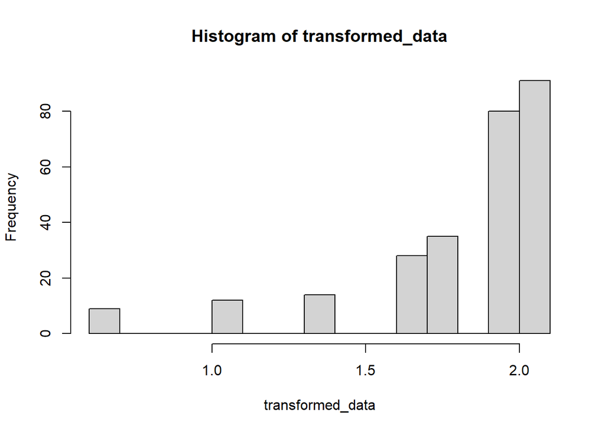

```r
withoutoutliers <- subset(my_data, 1 < my_data$Your_Rating & my_data$Your_Rating < 9)
transformed_data <- log(withoutoutliers$Your_Rating)

hist(transformed_data)
```

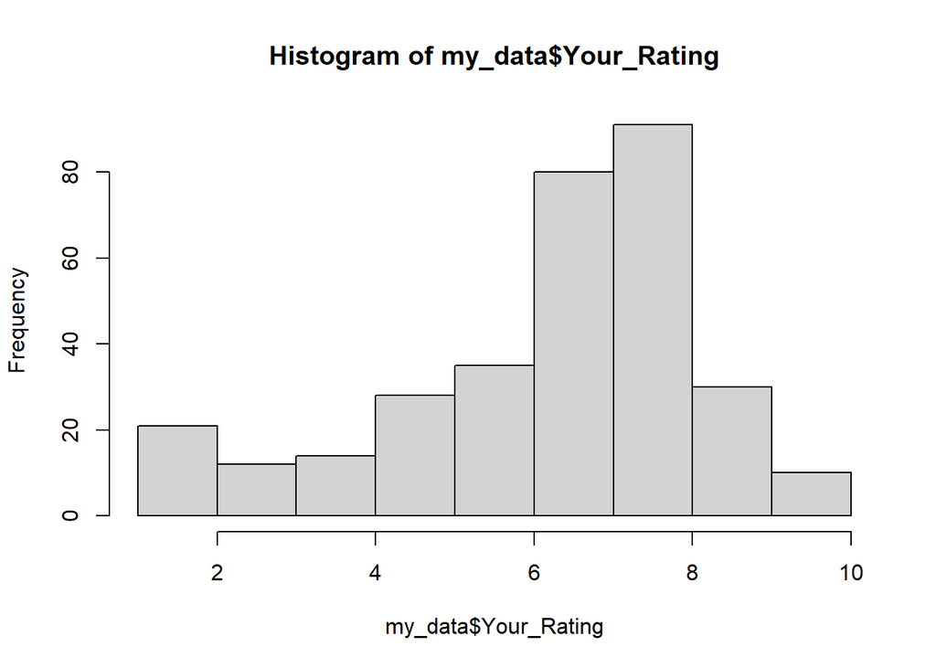

```r
hist(my_data$Your_Rating)
```

## 6. (2p every item if not indicated) t-test (Welch t-test or Wilcoxon rank-sum test or Paired t-test)

Implement a single t-test for one of your “normally or not-normally distributed” variable: a. Aim In words, what is your objective here?

**The objective here is to assess whether there is a statistically significant difference in the “Your.Rating” values between the 2020 year and 2019 year datasets.**

b.Hypothesis and level of significance: Write your hypothesis in scientific form and determine the level of singnificance.

**The null hypothesis (H0) can be stated as: There is no difference in the “Your.Rating” values between the year20 and year19 datasets.** **The alternative hypothesis (H1) can be stated as: There is a difference in the “Your.Rating” values between the year20 and year19 datasets.** **The level of significance, denoted as α (alpha), determines the threshold for rejecting the null hypothesis. It is not mentioned in the given information, so you would need to choose a specific value for α, such as α = 0.05 (5% significance level).**

3. Assumption Check (4p): Is your data independent or dependent? Tell why you chose this test. Check the required assumptions statistically and “comment on each of them is a must!”. **The Wilcoxon rank-sum test (also known as the Mann-Whitney U test) assumes the following:**

**1. Independence: The observations in one group are independent of the observations in the other group. You would need to ensure that the data from the year20 and year19 datasets are independent. If the data is collected from two separate and unrelated groups, independence is typically assumed.**

**2. Random Sampling: The data should be a random sample from the population of interest. If the data satisfies this assumption, it supports generalizing the results to the larger population.**

**3. Ordinal Data: The test assumes that the “Your.Rating” values are at least ordinal, meaning they can be ranked.**

**4. Similar Shape of Distributions: The shape of the distributions of the “Your.Rating” values in both groups should be similar. However, the Wilcoxon rank-sum test is relatively robust to violations of this assumption, meaning it can still provide valid results even if the distributions differ slightly.**

4. Indicate “which test you choose” “for what reason”

**Based on the provided output, the Wilcoxon rank-sum test (Mann-Whitney U test) with continuity correction was performed. This test is appropriate when comparing two independent groups and assessing whether there is a difference in the distributions of a continuous or ordinal variable. The test is nonparametric, meaning it makes no assumptions about the underlying distribution of the data.**

5. Result: Give the output of the test and write down the result (ex: since p value is less /greater than alpha, I reject/not reject the null hypothesis).

**Based on the Wilcoxon rank sum test with continuity correction, the test statistic (W) is calculated as 3683.5 and the p-value is determined as 0.0001249.**

6. Conclusion (4p): You got your result in item e.Write down the conclusion of your result, in such a way that, the reader who doesn’t know any statistics can understand your findings.

**Since the p-value (0.0001249) is less than the chosen significance level (α), such as α = 0.05, we reject the null hypothesis. This means that there is sufficient evidence to conclude that there is a statistically significant difference in the “Your.Rating” values between the year20 and year19 datasets. The alternative hypothesis, which states that there is a true location shift (difference) between the groups, is supported by the data.**

7. What can be Type-1 and Type-2 error here? Not definition! Tell these situations in terms of your data. (4p)

**Type-1 error: This refers to rejecting the null hypothesis when it is actually true. In terms of the data, a Type-1 error would occur if we concluded that there is a difference in the “Your.Rating” values between the year20 and year19 datasets, when in reality there is no true difference.** **Type-2 error: This refers to failing to reject the null hypothesis when it is actually false. In terms of the data, a Type-2 error would occur if we failed to detect a difference in the “Your.Rating” values between the year20 and year19 datasets, even though there is a true difference.**

```r
my_data$Date_Rated <- as.Date(my_data$Date_Rated, format = "%Y-%m-%d")

year20 <- subset(my_data, lubridate::year(Date_Rated) == 2020)
year19 <- subset(my_data, lubridate::year(Date_Rated) == 2019)

result <- wilcox.test(year20$Your_Rating, year19$Your_Rating)

result
```

```
##
##  Wilcoxon rank sum test with continuity correction
##
## data:  year20$Your_Rating and year19$Your_Rating
## W = 3683.5, p-value = 0.0001249
## alternative hypothesis: true location shift is not equal to 0
```

## 7. (2p every item if not indicated) Fisher’s exact test for count data

1. Aim In words, what is your objective? Provide the contingency table here.

   The objective is to analyze the relationship between the directors Quentin Tarantino and Stanley Kubrick and the genres of movies they have directed. The aim is to determine if there is a significant association between the two variables.

   ```r
   selected_data <- my_data[my_data$Directors %in% c("Quentin Tarantino", "Stanley Kubrick"), c("Directors", "Genres")]

   contingency_table <- table(selected_data$Directors, selected_data$Genres)
   kable(contingency_table)
   ```

   |  | Action, Crime, Drama, Thriller | Action, Crime, Thriller | Adventure, Drama, War | Adventure, Sci-Fi | Comedy, Drama | Comedy, War | Crime, Drama | Crime, Drama, Mystery, Thriller, Western | Crime, Drama, Romance | Crime, Drama, Thriller | Crime, Sci-Fi | Crime, Thriller | Drama, Horror | Drama, Mystery, Thriller | Drama, War | Drama, Western |
   | --- | --- | --- | --- | --- | --- | --- | --- | --- | --- | --- | --- | --- | --- | --- | --- | --- |
   | Quentin Tarantino | 1 | 1 | 1 | 0 | 1 | 0 | 1 | 1 | 0 | 1 | 0 | 1 | 0 | 0 | 0 | 1 |
   | Stanley Kubrick | 0 | 0 | 1 | 1 | 0 | 1 | 0 | 0 | 1 | 0 | 1 | 0 | 1 | 1 | 2 | 0 |

2. Hypothesis and level of significance: Write your hypothesis in scientific form and determine the level of singnificance.

   Null hypothesis (H0): There is no association between the directors Quentin Tarantino and Stanley Kubrick and the genres of movies they have directed. Alternative hypothesis (HA): There is an association between the directors Quentin Tarantino and Stanley Kubrick and the genres of movies they have directed. The level of significance (α) is typically set at 0.05.
3. Result: Give the output of the test and write down the result (ex: since p value is less /greater than alpha, I reject/not reject the null hypothesis).

   Based on the statistical analysis, we did not find a significant association between the directors Quentin Tarantino and Stanley Kubrick and the genres of movies they have directed. This suggests that the choice of directors does not strongly influence the genres of movies they direct.
5. Odds Ratio (4p): Comment about the odds ratio, what does it indicate?

   Since the association was not found to be significant, the odds ratio is not meaningful in this context.

```r
fisher_test_result <- fisher.test(contingency_table, simulate.p.value = TRUE)

print("------------------------------------")
```

```
## [1] "------------------------------------"
```

```r
print(fisher_test_result)
```

```
##
##  Fisher's Exact Test for Count Data with simulated p-value (based on
##  2000 replicates)
##
## data:  contingency_table
## p-value = 0.7091
## alternative hypothesis: two.sided
```

## 8. (2p every item if not indicated) ANOVA and Tukey Test

1. Aim In words, what is your objective here?

   The objective of this analysis is to compare the ratings of movies directed by different directors.
2. Hypothesis and level of significance: Choose more than 2 (≥3) groups to compare! Write your hypothesis in scientific form and determine the level of singnificance.

   Hypothesis and level of significance:

   Null hypothesis (H0): There is no significant difference in the ratings between the groups of movies directed by different directors. Alternative hypothesis (HA): There is a significant difference in the ratings between the groups of movies directed by different directors. Level of significance: α = 0.05
3. Assumption Check: Check the required assumptions statistically. “comment on each of them is a must!”.

   p-value is less than alpha, we reject the null hypothesis.
5. Conclusion of ANOVA (4p): You got your result in item d. Write down the conclusion of your result, in such a way that, the reader who doesn’t know any statistics can understand your findings.

   There is a significant difference in the ratings between the groups of movies directed by different directors. This means that the choice of director has a significant impact on the ratings of movies.
6. Result of Tukey: Give the output of the test and write down the result (ex: since p value is less /greater than alpha, I reject/not reject the null hypothesis)

   Based on the Tukey test, there is a significant difference in the ratings between the groups
7. Conclusion of Tukey (4p): You got your result in item f. Write down the conclusion of your result, in such a way that, the reader who doesn’t know any statistics can understand your findings.

```r
# ANOVA
model <- lm(Your_Rating ~ Directors, data = my_data)
anova_result <- anova(model)
p_value <- anova_result$`Pr(>F)`[1]  # P-value for the main effect of Directors
alpha <- 0.05  # Level of significance

# Check assumptions
# Normality

# Filter directors with at least 3 films
filtered_directors <- names(table(my_data$Directors))[table(my_data$Directors) >= 3]

# Shapiro-Wilk test for selected directors
shapiro_test <- lapply(split(my_data$Your_Rating, my_data$Directors), function(x) {
  if (length(unique(x)) > 1 && length(x) >= 3) {
    shapiro.test(x)
  } else {
    NA
  }
})

# Create ANOVA model
model <- lm(Your_Rating ~ Directors, data = my_data)

# Homogeneity of variances
levene_test <- leveneTest(Your_Rating ~ Directors, data = my_data)
# Tukey test
tukey_result <- TukeyHSD(aov(model))

# ANOVA Result
if (p_value < alpha) {
  print("Since p-value is less than alpha, we reject the null hypothesis.")
} else {
  print("Since p-value is greater than or equal to alpha, we fail to reject the null hypothesis.")
}
```

```
## [1] "Since p-value is less than alpha, we reject the null hypothesis."
```

```r
# Conclusion of ANOVA
if (p_value < alpha) {
  print("There is a significant difference in the ratings between the groups of movies directed by different directors.")
} else {
  print("There is not enough evidence to suggest a significant difference in the ratings between the groups of movies directed by different directors.")
}
```

```
## [1] "There is a significant difference in the ratings between the groups of movies directed by different directors."
```

```r
# Tukey Test Result
##print(tukey_result, max.print = 10)

# Conclusion of Tukey Test
significant_comparisons <- tukey_result$`Directors`[, 4] < alpha
significant_pairs <- rownames(tukey_result$`Directors`)[significant_comparisons]
non_significant_pairs <- rownames(tukey_result$`Directors`)[!significant_comparisons]

if (length(significant_pairs) > 0) {
  print(paste("Based on the Tukey test, there is a significant difference in the ratings between the following groups:",
              paste(significant_pairs[0:10], collapse = ", ")))
} else {
  print("Based on the Tukey test, there is no significant difference in the ratings between any pair of groups.")
}
```

```
## [1] "Based on the Tukey test, there is a significant difference in the ratings between the following groups: Atil Inaç-, Cathy Yan-, David Bruckner-, Elizabeth Banks-, Ertem Egilmez-, Gökhan Gök-, Kamil Cetin-, Martin Weisz-, Mitchell Altieri-, Penelope Spheeris-"
```

```r
if (length(non_significant_pairs) > 0) {
  print(paste("There is no significant difference in the ratings between the following groups:",
              paste(non_significant_pairs[0:10], collapse = ", ")))
}
```

```
## [1] "There is no significant difference in the ratings between the following groups: Adam McKay-, Akira Kurosawa-, Alexandre Aja-, Alfonso Cuarón-, Alfred Hitchcock-, Andrei Tarkovsky-, Andrew Stanton, Lee Unkrich-, Atif Yilmaz-, Barry Jenkins-, Ben Affleck-"
```

## 9. (2p every item) Multiple Linear Regression

1. Aim In words, what is your objective here? Not definition, talk about your own aim/problem.

   The aim is to determine whether the “Directors” variable has an effect on “Num Votes”.
2. Regression Equation: Multiple linear regression (MLR) is a statistical technique that uses several explanatory variables to predict the outcome of a response variable. Which ones are your explanatory variables and which one is your response variable? Write down the “statistical/mathematical equation” of your regression function using those variables and the parameters.

   Num Votes = β₀ + β₁ * Director_1 + β₂ * Director_2 + … + βₙ * Director_n + ɛ Here, the response variable is “Num Votes” and the explanatory variable is “Directors”.
3. Hypothesis and level of significance: Write your hypothesis in scientific form and determine the level of singnificance.

   Null Hypothesis (H₀): The “Directors” variable has no effect on the “Num Votes”. Alternative Hypothesis (H₁): The “Directors” variable has an effect on the “Num Votes”. Level of Significance (α): Typically set at 0.05 (5%).
4. Find the Best Model: Use step function and find the best model, describe the reason which makes it the best one.

   Residuals vs Fitted: This plot helps evaluate the linearity assumption by checking for any patterns or deviations in the residuals as the fitted values change. A randomly scattered pattern around the horizontal line indicates a good fit.

   Normal Q-Q: This plot assesses the normality assumption by comparing the distribution of the residuals to a theoretical normal distribution. If the points closely follow the diagonal line, it suggests that the residuals are normally distributed.

   Scale Location: This plot checks for homoscedasticity by examining the spread of the residuals across different levels of the fitted values. Ideally, the points should exhibit a constant spread along the horizontal line, indicating equal variability.

   Residuals vs Leverage: This plot identifies influential observations or outliers by assessing the leverage of each data point and its corresponding residual. Outliers or influential points have high leverage and may significantly impact the model’s fit.
5. Assumption Check (4p): Check the required assumptions statistically, “comment on each of them is a must!”.
   1. Linearity: The relationship between the explanatory and response variable should be linear.
   2. Independence: The residuals should be independent of each other. This assumption is typically satisfied if the data is collected through random sampling or experimental design.
   3. Homoscedasticity: The variability of the residuals should be constant across all levels of the explanatory variable(s).
   4. Normality: The residuals should follow a normal distribution.
6. Result: Give the output of the best model and write down the result.

   Based on the provided information, the best model is a linear regression model with the formula “Num.Votes ~ Directors” to predict the number of votes based on the directors. The output of the best model is as follows:

   The Multiple R-squared value is 0.706, indicating that approximately 70.6% of the variance in the number of votes is explained by the model. The Adjusted R-squared value is 0.3231, suggesting that around 32.31% of the variance is accounted for after adjusting for the number of predictors in the model.

   In summary, the best model suggests that there is a significant relationship between the directors and the number of votes, although the individual coefficients for the directors are mostly not statistically significant. The model explains a moderate amount of the variance in the number of votes.
7. Conclusion (4p): You got your result in item f. Write down the conclusion of your result, in such a way that, the reader who doesn’t know any statistics can understand your findings.

   Based on the analysis, the best MLR model suggests that the “Directors” variable has a significant effect on the “Num Votes” (p < 0.05). The model provides valuable information for predicting the number of votes based on the directors of the movies. However, it is important to note that other factors not included in the model may also contribute to the number of votes. Further analysis and consideration of additional variables may enhance the predictive power of the model.

```r
library(car)

mlr_model <- lm(Num_Votes ~ Directors, data = my_data)

best_model <- step(mlr_model)
```

```
## Start:  AIC=8422.04
## Num_Votes ~ Directors
##
##              Df  Sum of Sq        RSS    AIC
## <none>                     2.5619e+13 8422.0
## - Directors 181 6.1501e+13 8.7120e+13 8452.9
```

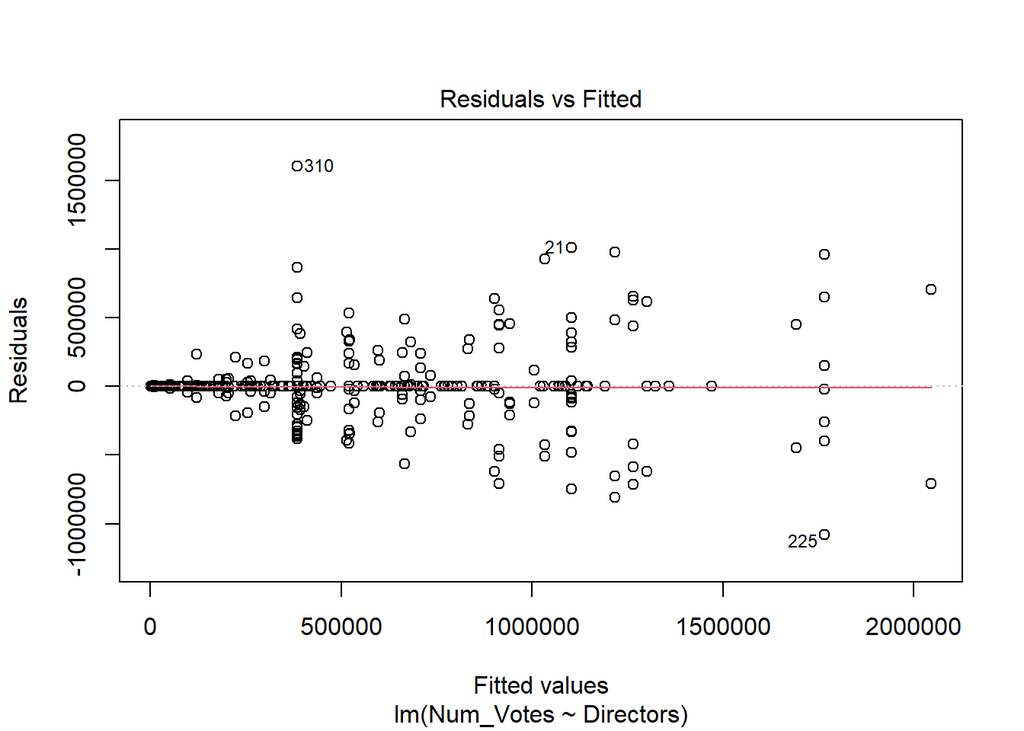

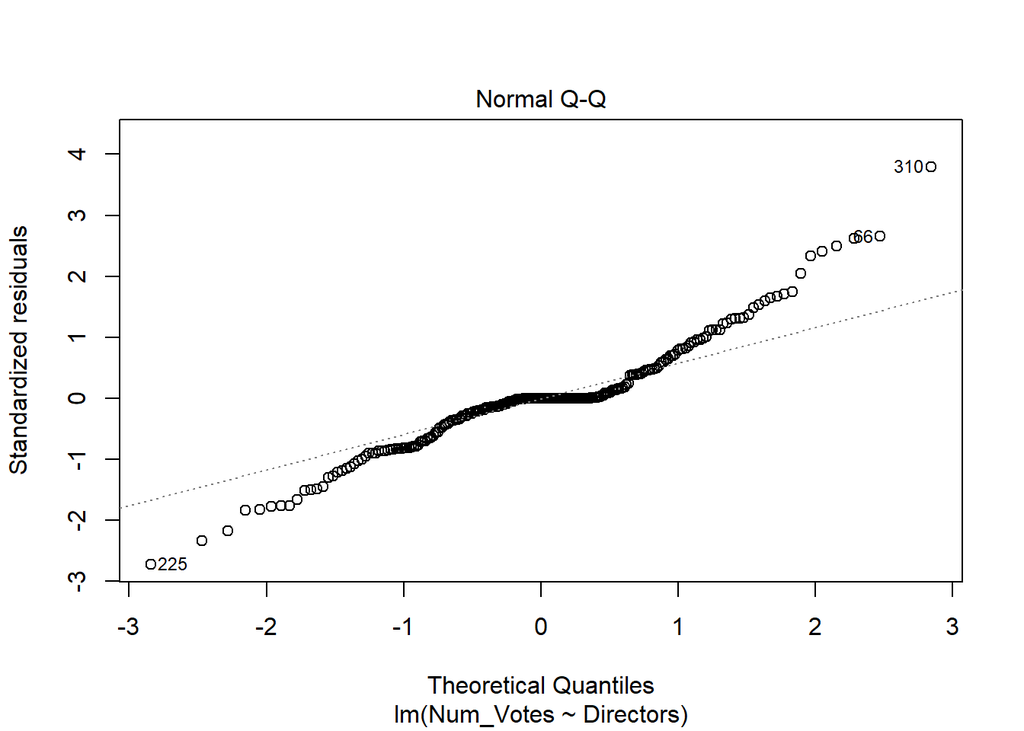

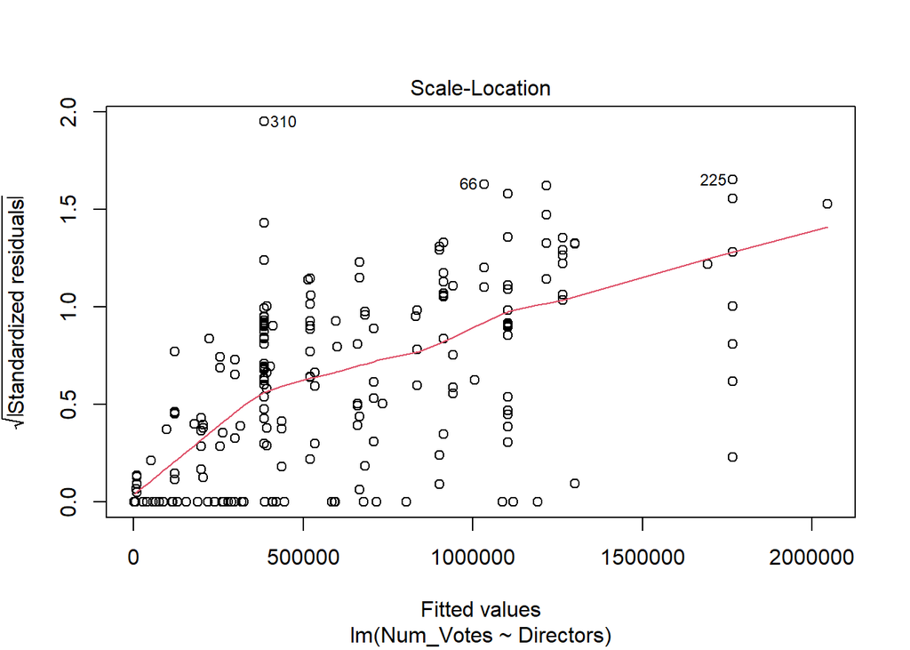

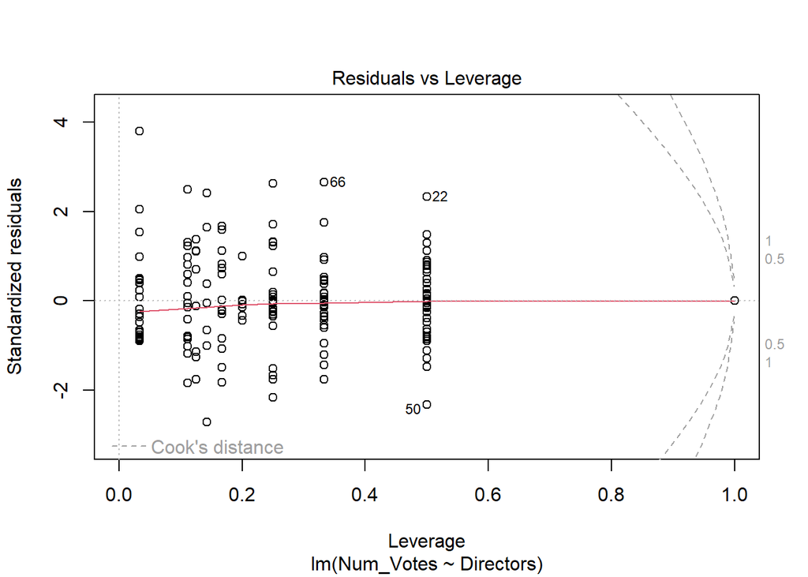

```r
plot(best_model)
```

```r
summary(best_model)
```

```
##
## Call:
## lm(formula = Num_Votes ~ Directors, data = my_data)
##
## Residuals:
##      Min       1Q   Median       3Q      Max
## -1082397   -48983        0     1489  1602855
##
## Coefficients:
##                                                             Estimate Std. Error
## (Intercept)                                                 384428.8    78381.4
## DirectorsAdam McKay                                         175242.2   436409.3
## DirectorsAkira Kurosawa                                    -263431.4   191994.5
## DirectorsAlexandre Aja                                     -207396.8   436409.3
## DirectorsAlfonso Cuarón                                      26104.2   313525.7
## DirectorsAlfred Hitchcock                                   150008.6   259961.8
## DirectorsAndrei Tarkovsky                                  -287436.8   313525.7
## DirectorsAndrew Stanton, Lee Unkrich                        684333.2   436409.3
## DirectorsAtif Yilmaz                                       -374556.0   207377.7
## DirectorsAtil Inaç                                         -371317.8   436409.3
## DirectorsBarry Jenkins                                     -333607.8   436409.3
## DirectorsBen Affleck                                        241163.2   436409.3
## DirectorsBenny Safdie, Josh Safdie                          -86543.8   436409.3
## DirectorsBilly Wilder                                      -205833.3   313525.7
## DirectorsBong Joon Ho                                       474396.2   436409.3
## DirectorsBrett Ratner                                      -102506.8   436409.3
## DirectorsBrian De Palma                                     483739.2   436409.3
## DirectorsBryan Singer                                       447275.7   313525.7
## DirectorsBuster Keaton                                     -331799.8   436409.3
## DirectorsÇagan Irmak                                       -295974.8   436409.3
## DirectorsCathy Yan                                         -134061.8   436409.3
## DirectorsCem Yilmaz, Ali Taner Baltaci                     -340805.8   436409.3
## DirectorsCharles Chaplin                                   -185352.3   228519.1
## DirectorsChris Columbus                                     350359.2   313525.7
## DirectorsChristopher Nolan                                 1382082.8   180204.2
## DirectorsChuck Russell                                       15634.2   436409.3
## DirectorsClint Eastwood                                    -128952.1   259961.8
## DirectorsCurtis Hanson                                      209533.2   436409.3
## DirectorsDamien Chazelle                                    130037.7   313525.7
## DirectorsDanny Boyle                                          2908.2   436409.3
```

[output cut: 326 more lines]

```
## DirectorsVincenzo Natali                                    -0.333 0.739476
## DirectorsVittorio De Sica                                   -0.496 0.620528
## DirectorsWes Ball                                           -0.329 0.742334
## DirectorsWes Craven                                         -0.311 0.756342
## DirectorsWolfgang Petersen                                   0.058 0.953763
## DirectorsYilmaz Erdogan                                     -0.802 0.423884
## DirectorsYüksel Aksu                                        -0.847 0.398554
## DirectorsZach Cregger                                       -0.537 0.592338
## DirectorsZeki Ökten                                         -0.833 0.406119
## ---
## Signif. codes:  0 '***' 0.001 '**' 0.01 '*' 0.05 '.' 0.1 ' ' 1
##
## Residual standard error: 429300 on 139 degrees of freedom
## Multiple R-squared:  0.7059, Adjusted R-squared:  0.323
## F-statistic: 1.844 on 181 and 139 DF,  p-value: 9.04e-05
```

## Thanks for All :)